# hsR Session 6: Regression Diagnostics & Assumptions in R

Nate Apathy

3/30/2018

# Regression Assumptions

1. Model is linear in the parameters
2. Samples are independent and random (implies no serial correlation in the errors)
3. Zero conditional mean of the error (expected value of residual is 0)
4. No multi-collinearity in the regressors
5. Homoskedasticity of the error terms
6. Errors normally distributed
7. No serial correlation in the errors
8. Non-zero sample variance in x

# Resources

- [Quick-R Tutorial](https://www.statmethods.net/stats/rdiagnostics.html)
- [R Stats Detailed Walkthrough](http://r-statistics.co/Assumptions-of-Linear-Regression.html)

# Checking Specific Assumptions

*Some of these we don’t need to “check,” like linearity in the parameters. That has to do with model specification, and by doing a linear model we are constraining the parameters (ß values) to be linear. Similarly, the second assumption relates to sampling approach, and we will get to its implications in #7.*

*We will be doing these exercises on the hixsamp.Rdata we created earlier in the lessons.*

## First Step: Create a regression!

- Using the hixsamp data frame, let’s make a basic model and then look at its adherence to the regression assumptions.

```r
# Build our regression
hixlm <- lm(PREMC2C30 ~ ST + factor(PLANTYPE) + METAL + factor(YEAR), data = hixsamp)

summary(hixlm)
```

```
##
## Call:
## lm(formula = PREMC2C30 ~ ST + factor(PLANTYPE) + METAL + factor(YEAR),
##     data = hixsamp)
##
## Residuals:
##     Min      1Q  Median      3Q     Max
## -669.49 -152.30    6.93  145.14 1311.33
##
## Coefficients:
##                   Estimate Std. Error t value Pr(>|t|)
## (Intercept)        878.985      9.289  94.629  < 2e-16 ***
## STMA               199.508      7.263  27.469  < 2e-16 ***
## factor(PLANTYPE)2 -269.832      7.632 -35.355  < 2e-16 ***
## factor(PLANTYPE)3  -82.025     24.826  -3.304 0.000960 ***
## factor(PLANTYPE)4  -42.312     11.940  -3.544 0.000398 ***
## METALCatastrophic -122.951     14.572  -8.438  < 2e-16 ***
## METALGold          530.865      9.743  54.486  < 2e-16 ***
## METALPlatinum      829.683     11.071  74.939  < 2e-16 ***
## METALSilver        235.444      9.552  24.650  < 2e-16 ***
## factor(YEAR)2017   130.370      6.609  19.727  < 2e-16 ***
## ---
## Signif. codes:  0 '***' 0.001 '**' 0.01 '*' 0.05 '.' 0.1 ' ' 1
##
## Residual standard error: 236.4 on 5409 degrees of freedom
## Multiple R-squared:  0.6684, Adjusted R-squared:  0.6679
## F-statistic:  1211 on 9 and 5409 DF,  p-value: < 2.2e-16
```

- Here we’ve modeled the Premium amount for a family with 2 kids and 2 parents above age 30 as a function of state (California or Massachussets), plan type (PPO, HMO, etc), and Metal tier.

## Zero Conditional Mean

- This is satisfied if the average residual value is at (or so small to effectively be) zero.

```r
mean(hixlm$residuals)
```

```
## [1] 1.429713e-14
```

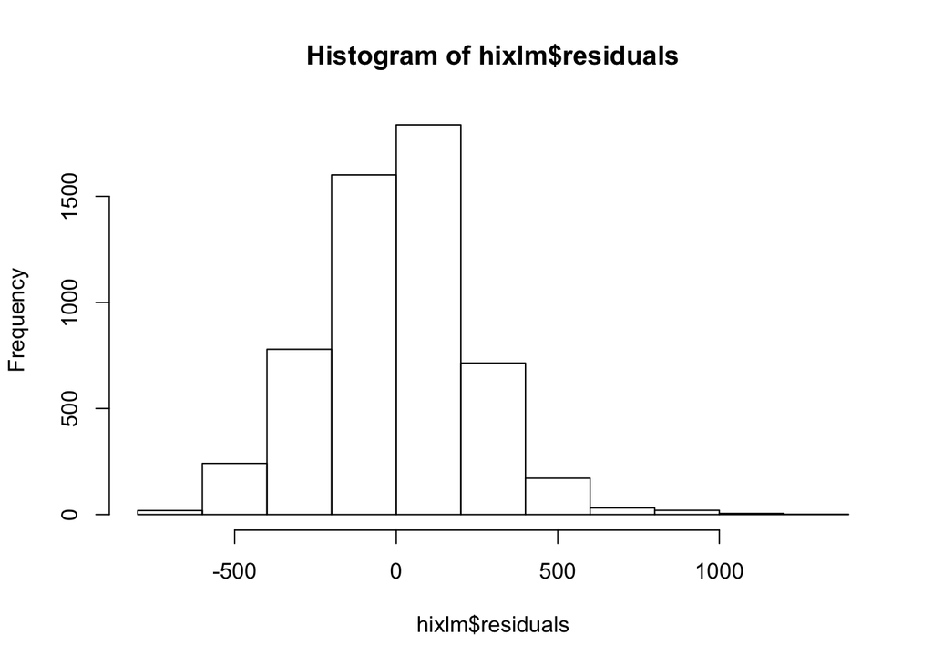

```r
# this appears to be satisfied because the value is so small

hist(hixlm$residuals)
```

## Normal Distribution of the Errors

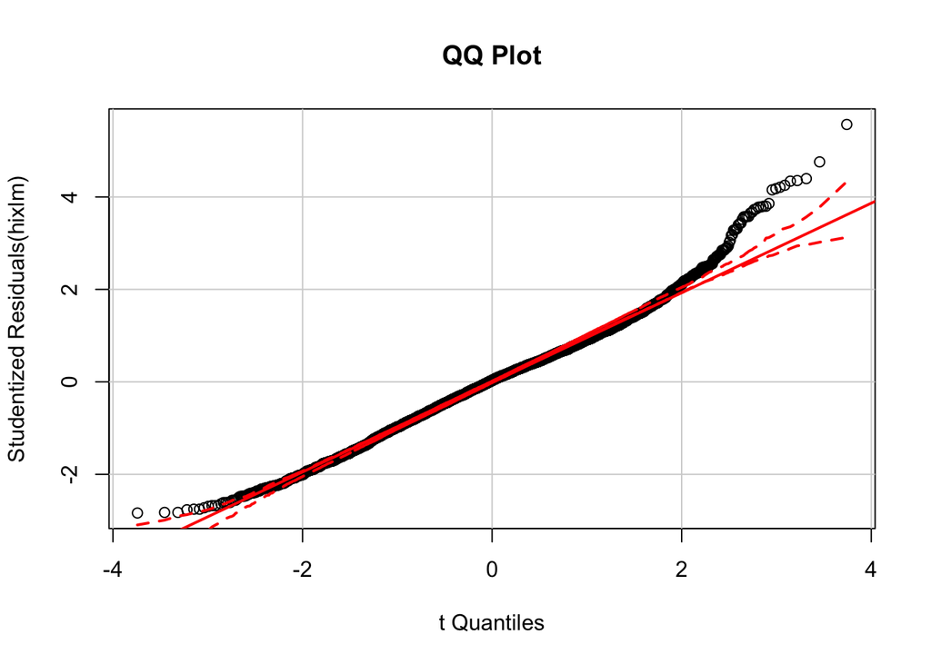

```r
# Normality of Residuals
# qq plot for studentized residual
qqPlot(hixlm, main="QQ Plot")
```

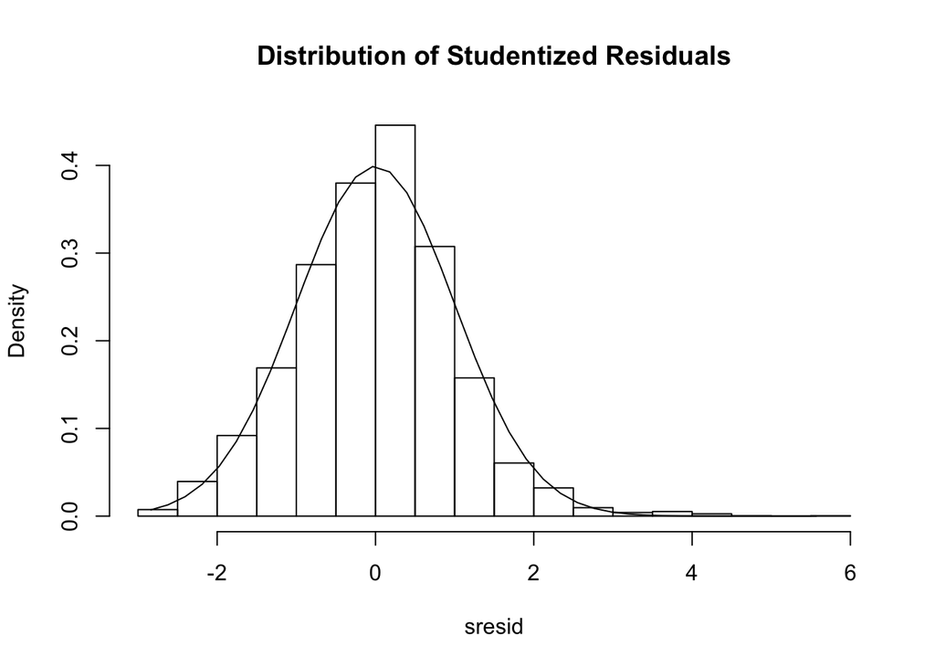

```r
# distribution of studentized residuals
sresid <- studres(hixlm)
hist(sresid, freq=FALSE,
   main="Distribution of Studentized Residuals")
xfit<-seq(min(sresid),max(sresid),length=40)
yfit<-dnorm(xfit)
lines(xfit, yfit)
```

## Check for Multi-collinearity using the VIF (Variance Inflation Factor)

```r
vif(hixlm)
```

```
##                      GVIF Df GVIF^(1/(2*Df))
## ST               1.272768  1        1.128170
## factor(PLANTYPE) 1.254905  3        1.038568
## METAL            1.121198  4        1.014402
## factor(YEAR)     1.058256  1        1.028716
```

## Plot Version

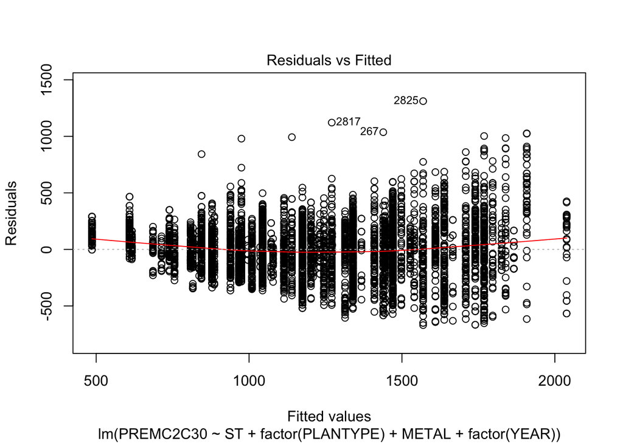

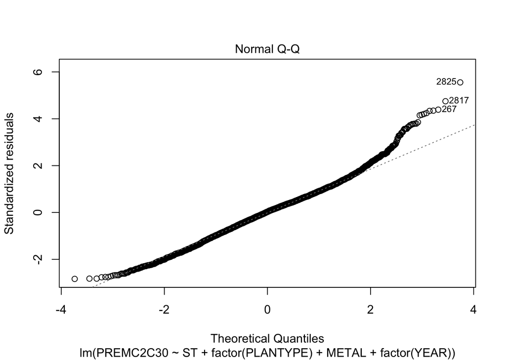

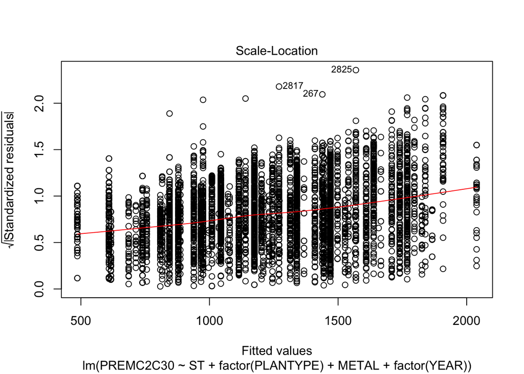

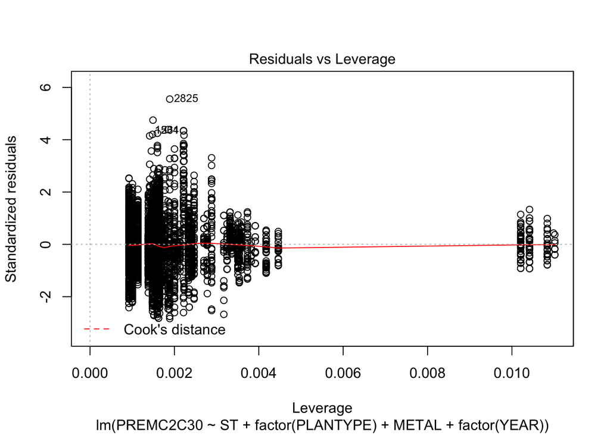

```r
plot(hixlm)
```

## Assessing Linearity of the Relationship

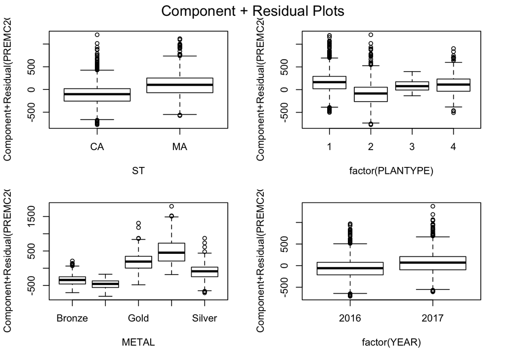

```r
# Evaluate Nonlinearity
# component + residual plot
crPlots(hixlm)
```